# 01.C: Data visualization with Matplotlib

Matplotlib is a comprehensive plotting library for creating static and/or interactive data visualizations. To start using it in a notebook like this, we tell Matplotlib to display the produced plots inside the notebook.

```python
%matplotlib inline
```

You can use `%matplotlib widget` if you want to interact with the generated plot. (It works pretty well)

Next we import Matplotlib. While we're at it, let's import NumPy and Pandas as well. There three packages work well together.

```python
import numpy as np
import pandas as pd
import matplotlib.pyplot as plt
```

## Line plots

Plots are two-dimensional, and we need x and y values: each of which is an array. Here are some random x values:

```python
x = np.sort(np.random.randint(1, 10, 20))
x
```

```
array([1, 1, 2, 2, 2, 3, 3, 3, 4, 6, 6, 6, 7, 8, 8, 8, 8, 8, 9, 9])
```

and some random y values:

```python
y = np.sort(np.random.randint(1, 100, 20))
y
```

```
array([ 6,  6, 26, 27, 32, 42, 43, 44, 47, 53, 53, 57, 58, 58, 59, 64, 75,
       75, 88, 91])
```

We can plot the above x and y arrays using the `plt.plot` function.

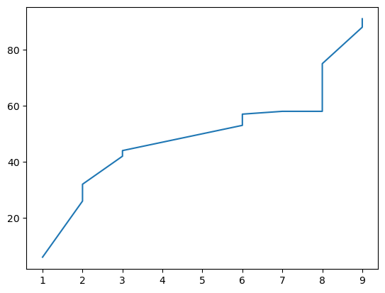

```python
plt.plot(x, y)
```

And we can re-plot these X an Y arrays, but this time we add a title and axes labels.

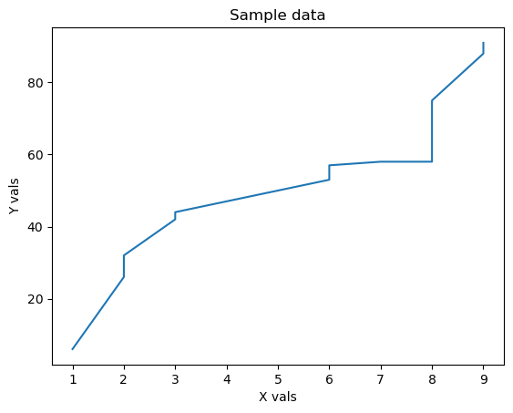

```python
plt.plot(x, y)
plt.title("Sample data")
plt.xlabel("X vals")
plt.ylabel("Y vals")
```

Let's style the plot. First we find out what styles are available.

```python
print(plt.style.available)
```

[output not shown]

Let's use the `ggplot` which is inspired by a poplar plotting library with the same name in R.

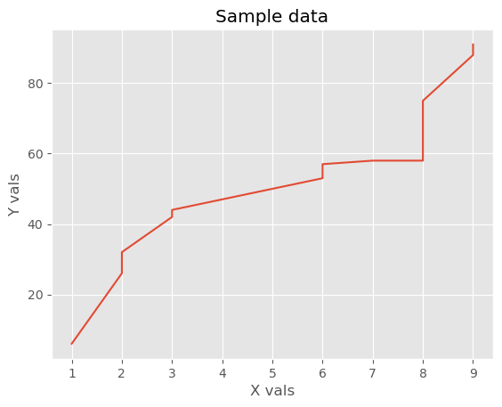

```python
plt.style.use('ggplot')
plt.plot(x, y)
plt.title("Sample data")
plt.xlabel("X vals")
plt.ylabel("Y vals")
```

Seaborn is a data visualization library based on Matplotlib. It provides a high-level interface for making attractive and informative plots. Here is the same plot as before using the style `seaborn`.

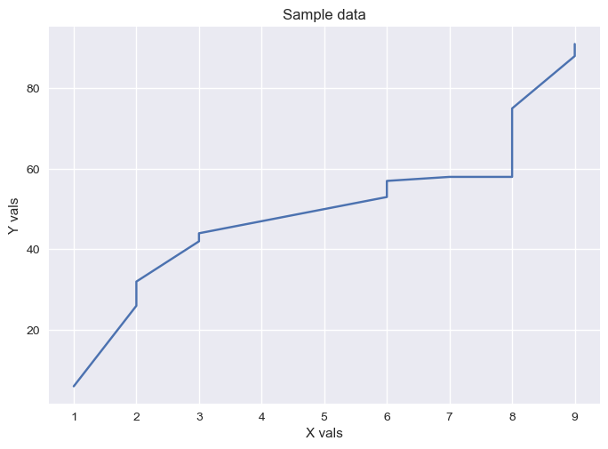

```python
plt.style.use('seaborn')
plt.plot(x, y)
plt.title("Sample data")
plt.xlabel("X vals")
plt.ylabel("Y vals")
```

We can call `plt.plot` multiple times if we have more than one X, Y data pairs.

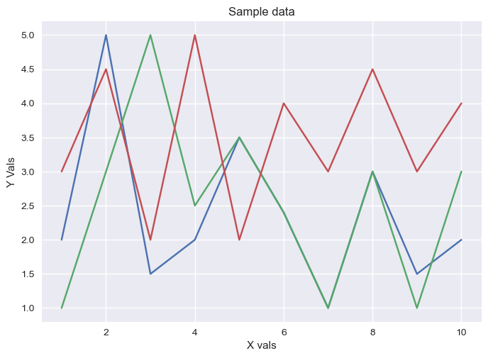

```python
plt.plot(
    [1,2,3,4,5,6,7,8,9,10],
    [2,5,1.5,2,3.5,2.4,1,3,1.5,2]
)

plt.plot(
    [1,2,3,4,5,6,7,8,9,10],
    [1,3,5,2.5,3.5,2.4,1,3,1,3]
)

plt.plot(
    [1,2,3,4,5,6,7,8,9,10],
    [3,4.5,2,5,2,4,3,4.5,3,4]
)

plt.title("Sample data")
plt.xlabel("X vals")
plt.ylabel("Y Vals")
```

We can also combine these three line plots into one `plot` call.

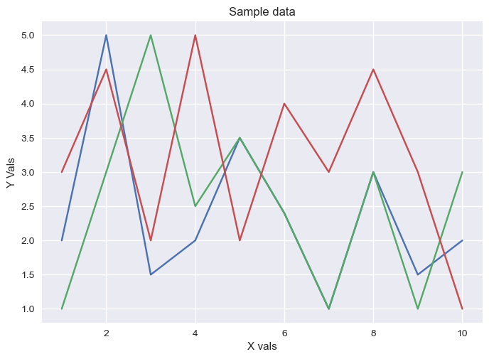

```python
plt.plot(
    [1,2,3,4,5,6,7,8,9,10], # x
    [2,5,1.5,2,3.5,2.4,1,3,1.5,2], # y
    [1,2,3,4,5,6,7,8,9,10], # x
    [1,3,5,2.5,3.5,2.4,1,3,1,3], # y
    [1,2,3,4,5,6,7,8,9,10], # x
    [3,4.5,2,5,2,4,3,4.5,3,1] # y
)

plt.title("Sample data")
plt.xlabel("X vals")
plt.ylabel("Y Vals")
```

Here, we need to label these plots so we know which one is which.

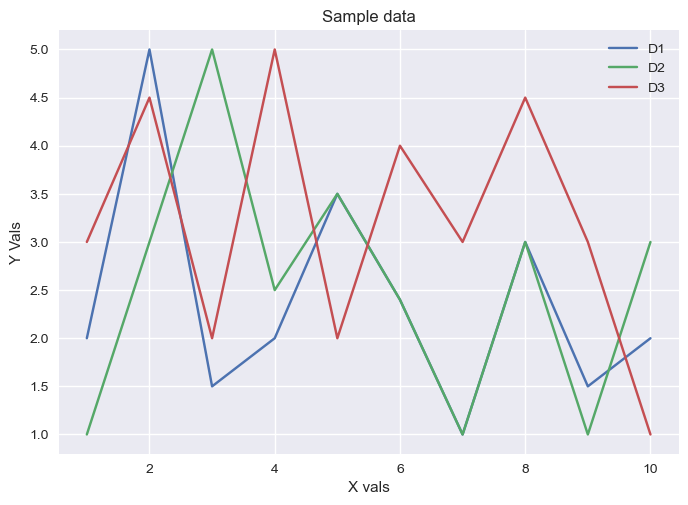

```python
plt.plot(
    [1,2,3,4,5,6,7,8,9,10],
    [2,5,1.5,2,3.5,2.4,1,3,1.5,2], label="D1"
)

plt.plot(
    [1,2,3,4,5,6,7,8,9,10],
    [1,3,5,2.5,3.5,2.4,1,3,1,3], label="D2"
)

plt.plot(
    [1,2,3,4,5,6,7,8,9,10],
    [3,4.5,2,5,2,4,3,4.5,3,1], label="D3"
)

plt.title("Sample data")
plt.xlabel("X vals")
plt.ylabel("Y Vals")
plt.legend()
```

And if we want to change the colors of these plots and how their line segments are drawn (dashed vs solid for example), we can do that too.

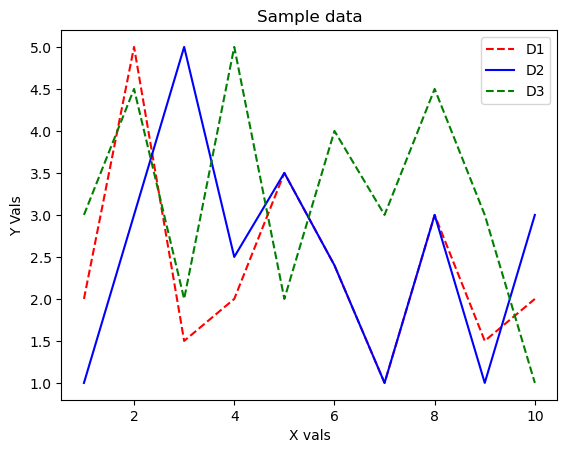

```python
plt.style.use('default')
plt.plot(
    [1,2,3,4,5,6,7,8,9,10],
    [2,5,1.5,2,3.5,2.4,1,3,1.5,2], 'r--', label="D1" # red dashed
)

plt.plot(
    [1,2,3,4,5,6,7,8,9,10],
    [1,3,5,2.5,3.5,2.4,1,3,1,3], 'b-', label="D2" # blue solid
)

plt.plot(
    [1,2,3,4,5,6,7,8,9,10],
    [3,4.5,2,5,2,4,3,4.5,3,1], 'g--', label="D3" # green dashed
)

plt.title("Sample data")
plt.xlabel("X vals")
plt.ylabel("Y Vals")
plt.legend()
```

## Histograms and bar plots

Given some random data:

```python
data = np.random.randint(1,11,100)
```

We can plot a histogram of it.

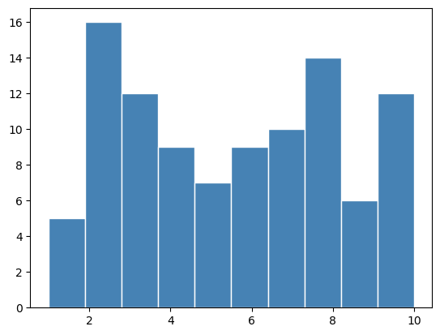

```python
plt.hist(data, color='steelblue', edgecolor='white')
```

We can similarly create bar charts

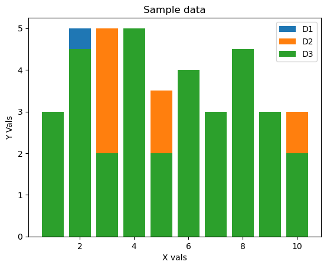

```python
plt.bar(
    [1,2,3,4,5,6,7,8,9,10],
    [2,5,1.5,2,3.5,2.4,1,3,1.5,2], label="D1",
)

plt.bar(
    [1,2,3,4,5,6,7,8,9,10],
    [1,3,5,2.5,3.5,2.4,1,3,1,3], label="D2",
)

plt.bar(
    [1,2,3,4,5,6,7,8,9,10],
    [3,4.5,2,5,2,4,3,4.5,3,2], label="D3",
)

plt.title("Sample data")
plt.xlabel("X vals")
plt.ylabel("Y Vals")
plt.legend()
```

## Scatter plots

We can easily create a scatter plot of some random data using the `.scatter` function.

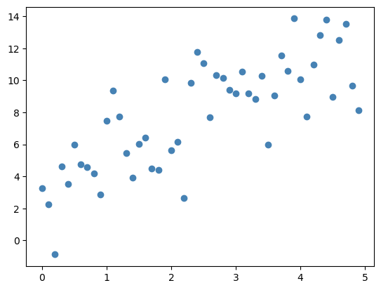

```python
x = np.arange(0, 5, .1)
x = x.reshape(x.size, 1)
y = 2 * x + 2 + np.random.normal(loc=1, scale=2, size=(x.size, 1))
plt.scatter(x, y, color='steelblue', marker='o')
```

## Figures and subplots

It's recommended, when using Matplotlib, to start with creating a figure object and then use that figure object to create one or more subplots. Let's start by creating a figure:

```python
fig = plt.figure()
```

This creates a figure object with the default size. We can create a figure with a custom figure size (in inches) like this.

```python
fig = plt.figure(figsize=(16,9))
```

We can now use this figure to create a subplot.

```python
ax = fig.add_subplot(1, 1, 1)
```

The first two arguments to `add_subplot` determine how many subplots we have. Think of subplots as a 2D array. A $1 \times 1$ means a single subplot, a $1 \times 2$ contains two subplots side by side, and a $2 \times 2$ means 4 subplots: two rows and two columns.

The third argument to `add_subplot` tells Matplotlib which subplot we are plotting into.

Let's now draw the scatter plot above into this figure. We'll used a different style.

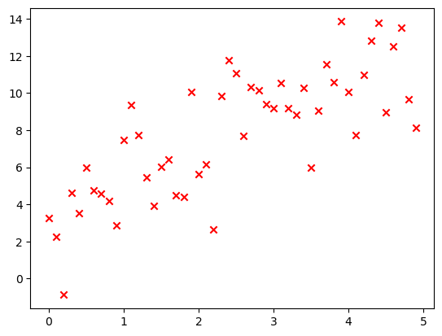

```python
plt.scatter(x, y, color='r', marker='x')
```

And here is an example with multiple subplots:

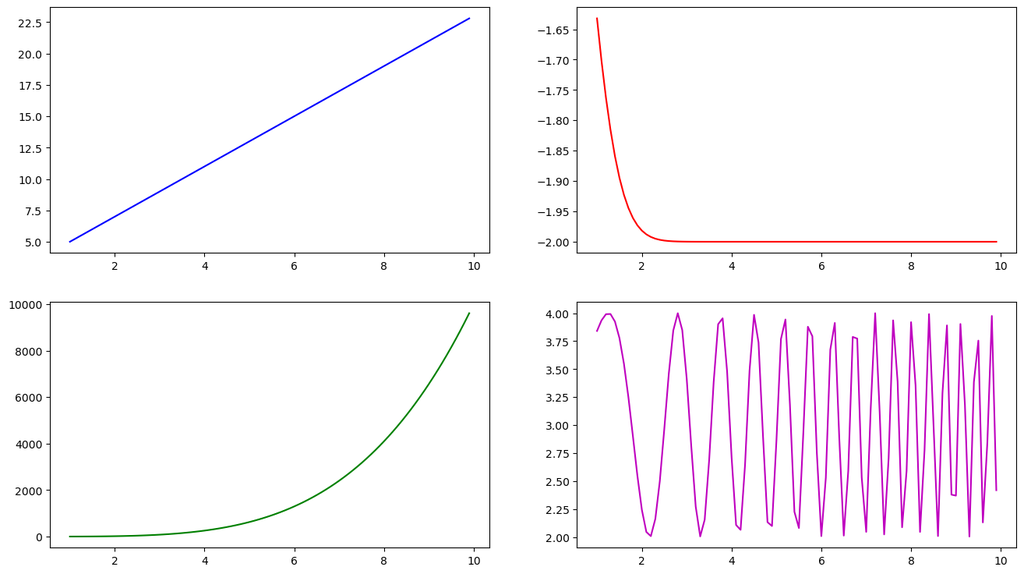

```python
fig = plt.figure(figsize=(16,9))

ax = fig.add_subplot(2, 2, 1) # First subplot

x = np.arange(1, 10 ,0.1)
ax.plot(x, 3 + x*2, 'b-')

ax = fig.add_subplot(2, 2, 2) # Second subplot
ax.plot(x, -2 + np.exp(-x**2), 'r-')


ax = fig.add_subplot(2, 2, 3) # Third subplot
ax.plot(x, 3 + x**4, 'g-')

ax = fig.add_subplot(2, 2, 4) # Fourth subplot
ax.plot(x, 3 + np.sin(x**2), 'm-')
```

Here we can use the `ax` object returned by `fig.add_subplot` to customize that particular plot.

The above could also be done using `plt.subplots`, which creates a figure with the requested number of subplots.

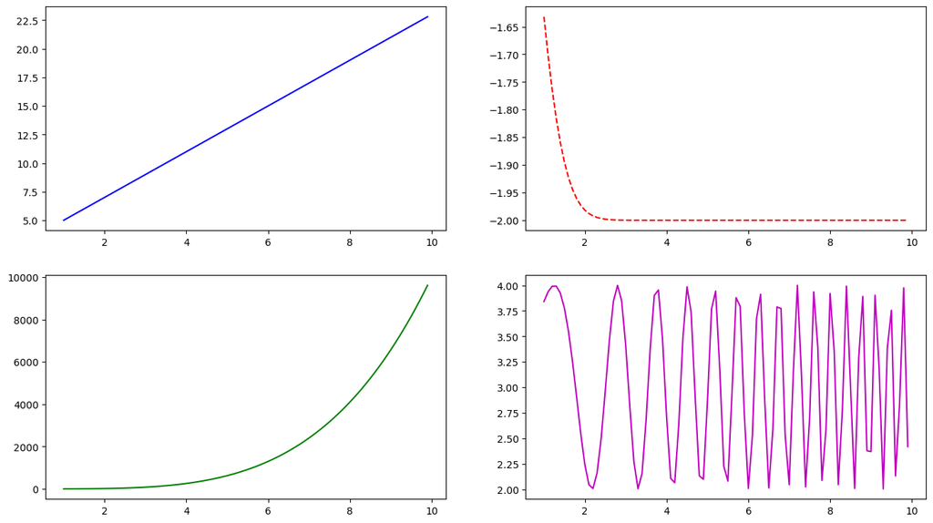

```python
fig, axes = plt.subplots(2, 2) # Creates a figure and 2 by 2 array of subplots
fig.set_size_inches(16, 9)
x = np.arange(1, 10 ,0.1)
axes[0,0].plot(x, 3 + x*2, 'b-')  # First subplot

axes[0,1].plot(x, -2 + np.exp(-x**2), 'r--') # Second subplot

axes[1, 0].plot(x, 3 + x**4, 'g-') # Third subplot

axes[1,1].plot(x, 3 + np.sin(x**2), 'm-') # Fourth subplot
```

And here we can use the `axes` array returned by `fig.subplots` to customize any of the created subplots.

## EXERCISE

Use scatter plots to draw the following functions in a $2 by 2$ subplot array. Each plot must have its own title, and its own x and y labels,

- $f(x) = 3 x^2 + 10$
- $f(x) = \frac{1}{1 + e^{-x}}$
- $f(x) = max(0, x)$
- $f(x) = tanh(x)$

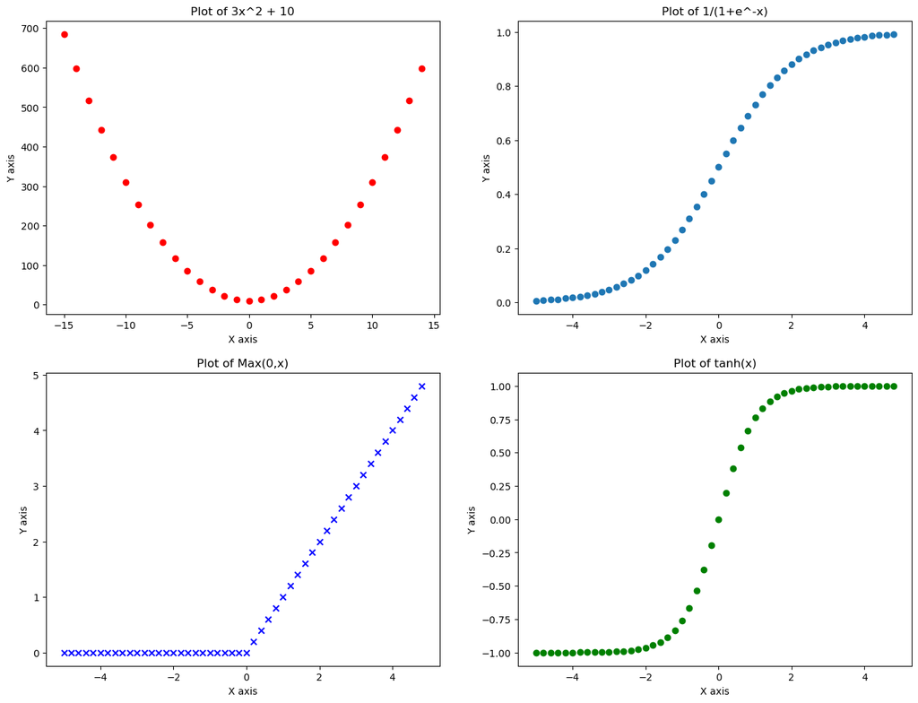

```python
# TODO
fig, axes = plt.subplots(2,2)
fig.set_size_inches(16,12)

# create values for the x axis that make sense for the functions given
x1 = np.arange(-15,15,1)
x2 = np.arange(-5,5,.2)
x3 = np.arange(-1,1,.1)


# use either pow(num, exp) or ** for exponents
axes[0,0].scatter(x1, 3 * x1**2 + 10, color='r') # top left plot
axes[0,0].set_title("Plot of 3x^2 + 10")
axes[0,0].set_xlabel("X axis")
axes[0,0].set_ylabel("Y axis")

axes[0,1].scatter(x2, 1/(1 + np.exp(-x2))) # top right plot
axes[0,1].set_title("Plot of 1/(1+e^-x)")
axes[0,1].set_xlabel("X axis")
axes[0,1].set_ylabel("Y axis")

axes[1,0].scatter(x2, np.maximum(0,x2), color='b', marker='x') # bottom left
axes[1,0].set_title("Plot of Max(0,x)")
axes[1,0].set_xlabel("X axis")
axes[1,0].set_ylabel("Y axis")

axes[1,1].scatter(x2, np.tanh(x2), color='g') # bottom right plot
axes[1,1].set_title("Plot of tanh(x)")
axes[1,1].set_xlabel("X axis")
axes[1,1].set_ylabel("Y axis")
```